# Jeff2

https://github.com/jrkkv5/FIN6572Fall2020/blob/master/National%20Debt/importNationalDebt.Rmd

11/28/2020

```r
#Loading necessary packages
library(readr)
library(devtools)
library(blsAPI)
library(rjson)
library(curl)
library(dplyr)
library(tidyverse)
library(rmarkdown)
library(knitr)
library(pastecs)
```

```r
library(ggplot2)
library(corrplot)
library(lmtest)
#Update code for your states and run regression from 1984-2014, create some basic plots, etc.
```

```r
merged_final <- read_csv("csv files/mergedFinal.csv")
#Reads final file into merged dataframe

merged_final$log_pop = log(merged_final$population)

merged_final$log_RMHI = log(merged_final$RMHI)
```

As a final step in scrubbing our data, we created new variables to log the population and median household income variables and store it in our dataframe. By taking the logarithmic values, these variables become more comparable to the existing variables we have within our dataset.

Below you can see the table output once all of our data has been merged.

```r
kable(merged_final[1:6,], caption = "Table Including All Variables")
```

Table Including All Variables

| year | period | periodName | value | state | quarter | annual | HPI | MHI | RMHI | poverty | population | sp500 | log_pop | log_RMHI |
| --- | --- | --- | --- | --- | --- | --- | --- | --- | --- | --- | --- | --- | --- | --- |
| 1984 | M12 | December | 9.3 | AK | 4 | 1 | 153.82 | 32356 | 74689 | 9.6 | 513702 | 1.40 | 13.14940 | 11.22109 |
| 1985 | M12 | December | 10.1 | AK | 4 | 1 | 143.07 | 34782 | 77625 | 8.7 | 532495 | 26.33 | 13.18533 | 11.25964 |
| 1986 | M12 | December | 11.0 | AK | 4 | 1 | 138.24 | 31356 | 68775 | 11.4 | 544268 | 14.62 | 13.20720 | 11.13860 |
| 1987 | M12 | December | 9.5 | AK | 4 | 1 | 106.02 | 33233 | 70468 | 12.0 | 539309 | 2.03 | 13.19804 | 11.16291 |
| 1988 | M12 | December | 8.0 | AK | 4 | 1 | 133.16 | 33103 | 67745 | 11.0 | 541983 | 12.40 | 13.20299 | 11.12351 |
| 1989 | M12 | December | 7.1 | AK | 4 | 1 | 102.92 | 36006 | 70599 | 10.5 | 547159 | 27.25 | 13.21249 | 11.16477 |

After our data was merged we binned the states into groups based on the mean population of the years in our dataframe (1984-2018). Below are the bins that were created:

Population < 2,000,000 WV, NM, NE, ID, ME, HI, NH, RI, MT, DE, SD, ND, AK, VT, WY

2,000,000 < Population < 5,000,000 MN, AL, LA, CO, SC, KY, OK, OR, CT, IA, MS, KS, AR, UT, NV

5,000,000 < Population < 10,000,000 MI, NJ, GA, NC, VA, MA, IN, WA, TN, MO, WI, MD, AZ

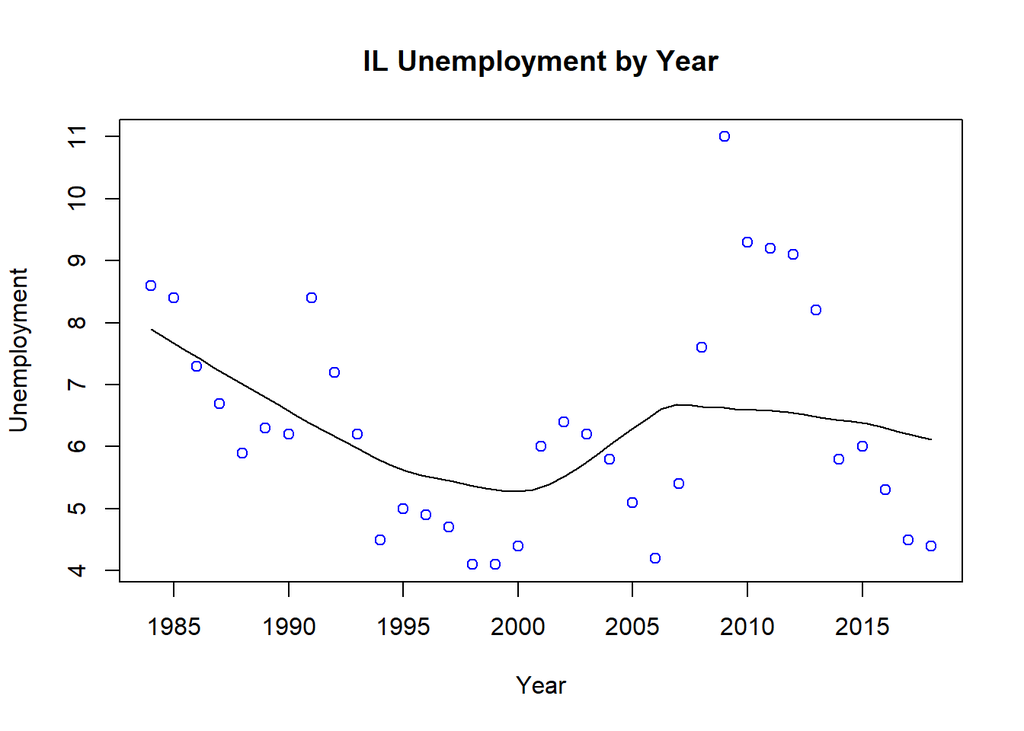

```r
IL_data <- merged_final[ merged_final$state == "IL", ]

scatter.smooth(IL_data$year, IL_data$value, main="IL Unemployment by Year", xlab = "Year", ylab = "Unemployment", col = "blue", span = 2/3)
```

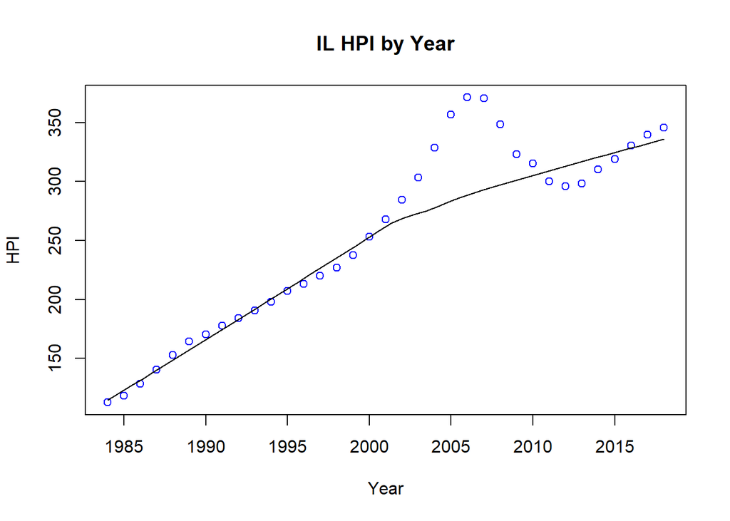

```r
scatter.smooth(IL_data$year, IL_data$HPI, main="IL HPI by Year", xlab = "Year", ylab = "HPI", col = "blue")
```

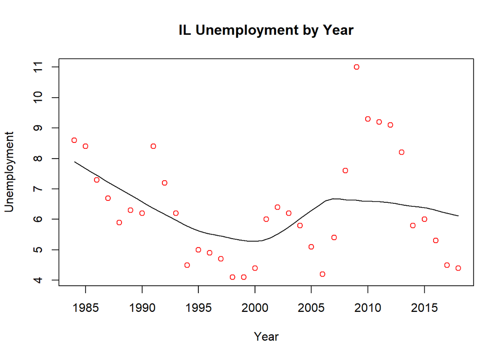

```r
scatter.smooth(x=IL_data$year, y=IL_data$value, main="IL Unemployment by Year", xlab = "Year", ylab = "Unemployment", col = "red")
```

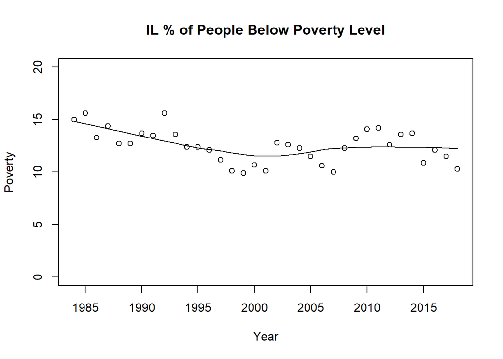

```r
scatter.smooth(x=IL_data$year, y=IL_data$poverty, main="IL % of People Below Poverty Level", xlab = "Year", ylab = "Poverty", ylim = c(0,20))
```

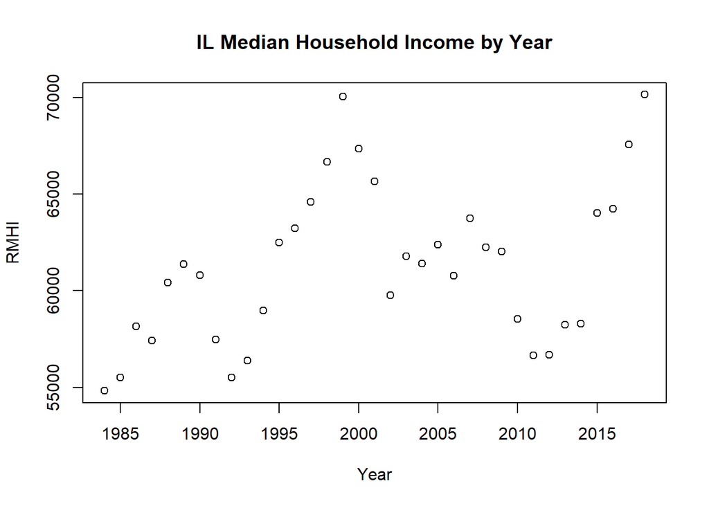

```r
IL_data$RMHI <- as.integer(IL_data$RMHI)
plot(x=IL_data$year, y=IL_data$RMHI, main="IL Median Household Income by Year", xlab = "Year", ylab = "RMHI" )
```

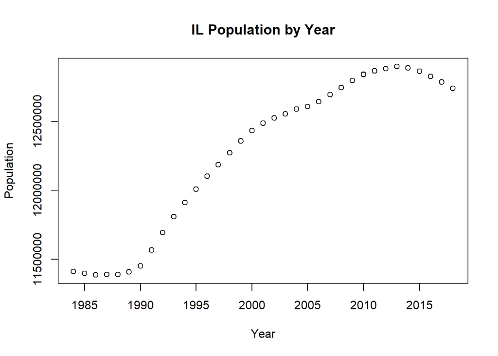

```r
IL_data$population <- as.integer(IL_data$population)
plot(x=IL_data$year, y=IL_data$population, main="IL Population by Year", xlab = "Year", ylab = "Population" )
```

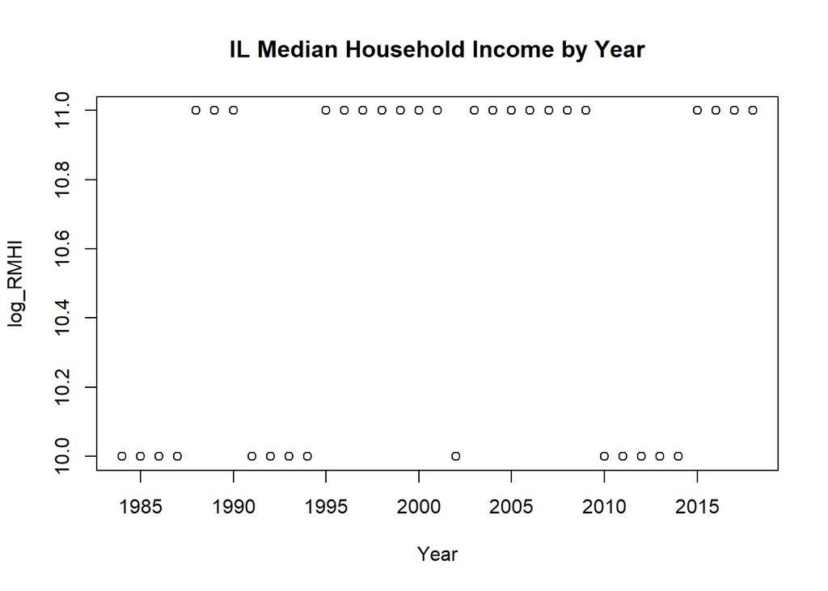

```r
IL_data$log_RMHI <- as.integer(IL_data$log_RMHI)
plot(x=IL_data$year, y=IL_data$log_RMHI, main="IL Median Household Income by Year", xlab = "Year", ylab = "log_RMHI" )
```

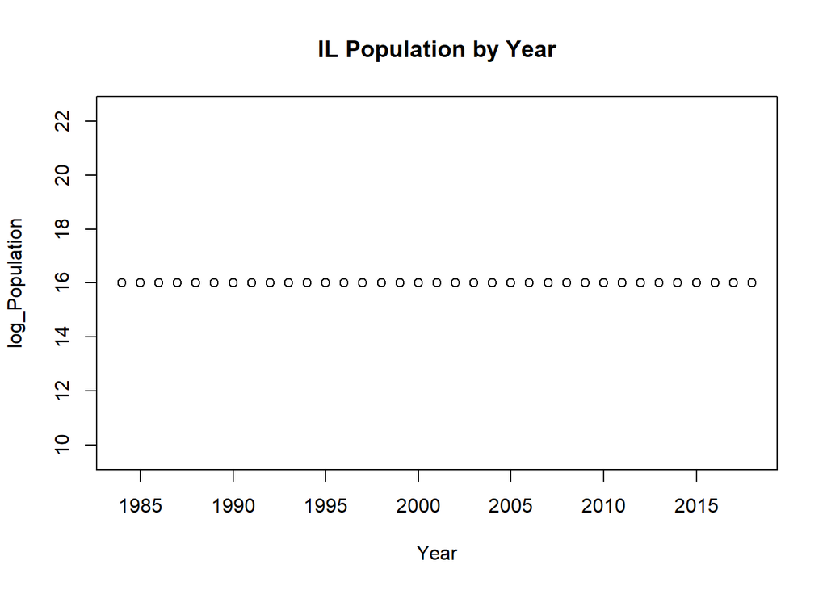

```r
IL_data$log_pop <- as.integer(IL_data$log_pop)
plot(x=IL_data$year, y=IL_data$log_pop, main="IL Population by Year", xlab = "Year", ylab = "log_Population" )
```

```r
cor(IL_data$RMHI, IL_data$value)
```

```
## [1] -0.6590005
```

```r
cor(IL_data$HPI, IL_data$value)
```

```
## [1] -0.08115831
```

```r
cor(IL_data$poverty, IL_data$value)
```

```
## [1] 0.6975789
```

```r
cor(IL_data$population, IL_data$value)
```

```
## [1] 0.02011968
```

```r
cor(IL_data$sp500, IL_data$value)
```

```
## [1] 0.03109792
```

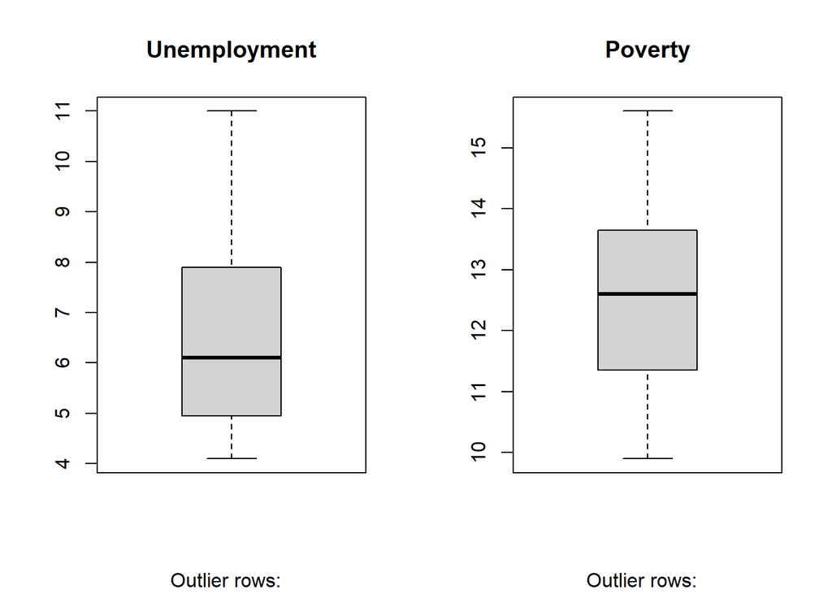

```r
#run base correlations between categories and dependent variable

par(mfrow=c(1, 2))  # divide graph area in 2 columns
boxplot(IL_data$value, main="Unemployment", sub=paste("Outlier rows: ", boxplot.stats(IL_data$value)$out))  # box plot for 'Unemployment'
boxplot(IL_data$poverty, main="Poverty", sub=paste("Outlier rows: ", boxplot.stats(IL_data$poverty)$out))  # box plot for 'Poverty'
```

```r
#create box plot for poverty level and unemployment level

#run multiple linear model for data
IL_reg1 <- lm(value ~ poverty + RMHI + HPI + population + sp500, data = IL_data)
summary(IL_reg1)
```

```
##
## Call:
## lm(formula = value ~ poverty + RMHI + HPI + population + sp500,
##     data = IL_data)
##
## Residuals:
##     Min      1Q  Median      3Q     Max
## -2.5866 -0.7214 -0.0935  0.7777  3.6103
##
## Coefficients:
##               Estimate Std. Error t value Pr(>|t|)
## (Intercept) -1.676e+01  1.379e+01  -1.215   0.2337
## poverty      6.896e-01  2.776e-01   2.484   0.0188 *
## RMHI        -1.113e-04  1.033e-04  -1.077   0.2901
## HPI         -5.417e-03  8.027e-03  -0.675   0.5050
## population   1.851e-06  1.075e-06   1.723   0.0952 .
## sp500        2.284e-04  1.343e-02   0.017   0.9865
## ---
## Signif. codes:  0 '***' 0.001 '**' 0.01 '*' 0.05 '.' 0.1 ' ' 1
##
## Residual standard error: 1.217 on 30 degrees of freedom
## Multiple R-squared:  0.6143, Adjusted R-squared:  0.5501
## F-statistic: 9.558 on 5 and 30 DF,  p-value: 1.561e-05
```

```r
anova(IL_reg1)
```

```
## Analysis of Variance Table
##
## Response: value
##            Df Sum Sq Mean Sq F value    Pr(>F)
## poverty     1 56.050  56.050 37.8541 9.109e-07 ***
## RMHI        1  1.303   1.303  0.8798   0.35574
## HPI         1  8.899   8.899  6.0102   0.02026 *
## population  1  4.510   4.510  3.0461   0.09117 .
## sp500       1  0.000   0.000  0.0003   0.98654
## Residuals  30 44.420   1.481
## ---
## Signif. codes:  0 '***' 0.001 '**' 0.01 '*' 0.05 '.' 0.1 ' ' 1
```

```r
IL_reg2 <- lm(value ~ poverty + log_RMHI + HPI + log_pop + sp500, data = IL_data)
summary(IL_reg2)
```

```
##
## Call:
## lm(formula = value ~ poverty + log_RMHI + HPI + log_pop + sp500,
##     data = IL_data)
##
## Residuals:
##     Min      1Q  Median      3Q     Max
## -2.3129 -0.8067 -0.0729  0.7785  3.6142
##
## Coefficients: (1 not defined because of singularities)
##              Estimate Std. Error t value Pr(>|t|)
## (Intercept) -1.773194   8.903473  -0.199 0.843440
## poverty      0.869769   0.213235   4.079 0.000293 ***
## log_RMHI    -0.439202   0.636031  -0.691 0.494996
## HPI          0.007466   0.003119   2.394 0.022913 *
## log_pop            NA         NA      NA       NA
## sp500        0.004188   0.013829   0.303 0.764050
## ---
## Signif. codes:  0 '***' 0.001 '**' 0.01 '*' 0.05 '.' 0.1 ' ' 1
##
## Residual standard error: 1.26 on 31 degrees of freedom
## Multiple R-squared:  0.5725, Adjusted R-squared:  0.5174
## F-statistic: 10.38 on 4 and 31 DF,  p-value: 1.876e-05
```

```r
anova(IL_reg2)
```

```
## Analysis of Variance Table
##
## Response: value
##           Df Sum Sq Mean Sq F value    Pr(>F)
## poverty    1 56.050  56.050 35.2909 1.453e-06 ***
## log_RMHI   1  0.743   0.743  0.4681   0.49896
## HPI        1  9.009   9.009  5.6724   0.02356 *
## sp500      1  0.146   0.146  0.0917   0.76405
## Residuals 31 49.235   1.588
## ---
## Signif. codes:  0 '***' 0.001 '**' 0.01 '*' 0.05 '.' 0.1 ' ' 1
```

```r
IL_linearModelSignificant <- lm(value ~ poverty + population, data = IL_data)
summary(IL_linearModelSignificant)
```

```
##
## Call:
## lm(formula = value ~ poverty + population, data = IL_data)
##
## Residuals:
##     Min      1Q  Median      3Q     Max
## -2.4596 -0.7213 -0.1496  0.7137  3.3309
##
## Coefficients:
##               Estimate Std. Error t value Pr(>|t|)
## (Intercept) -1.996e+01  5.728e+00  -3.485  0.00141 **
## poverty      9.669e-01  1.388e-01   6.964 5.83e-08 ***
## population   1.162e-06  3.903e-07   2.976  0.00543 **
## ---
## Signif. codes:  0 '***' 0.001 '**' 0.01 '*' 0.05 '.' 0.1 ' ' 1
##
## Residual standard error: 1.189 on 33 degrees of freedom
## Multiple R-squared:  0.5953, Adjusted R-squared:  0.5707
## F-statistic: 24.27 on 2 and 33 DF,  p-value: 3.3e-07
```

```r
#test to show a scatterplot IL HPI data against year
```

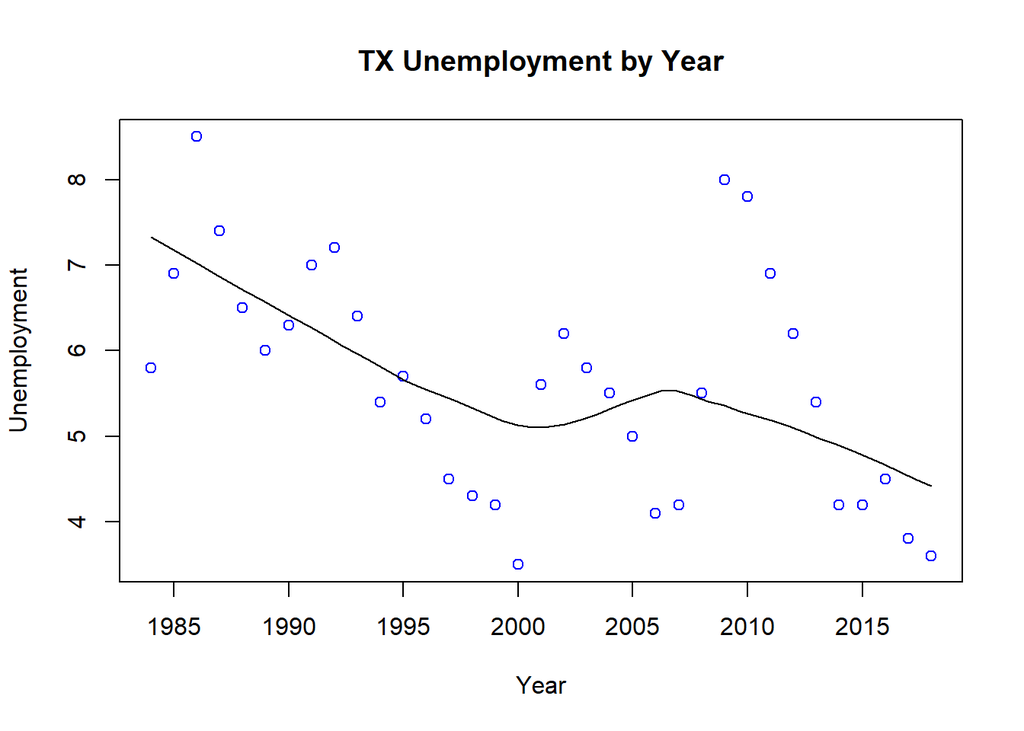

```r
TX_data <- merged_final[ merged_final$state == "TX", ]

scatter.smooth(TX_data$year, TX_data$value, main="TX Unemployment by Year", xlab = "Year", ylab = "Unemployment", col = "blue", span = 2/3)
```

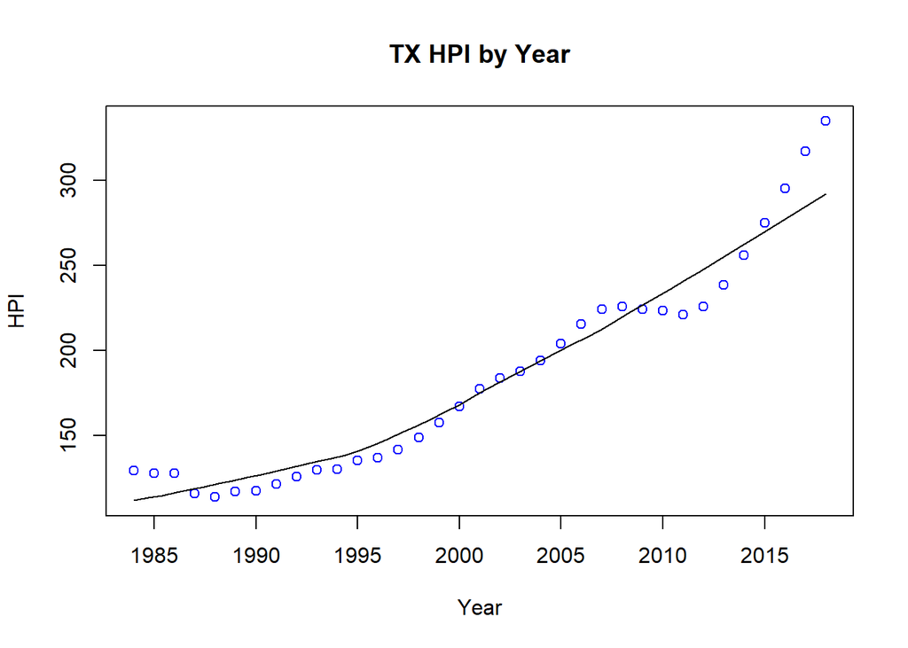

```r
scatter.smooth(TX_data$year, TX_data$HPI, main="TX HPI by Year", xlab = "Year", ylab = "HPI", col = "blue")
```

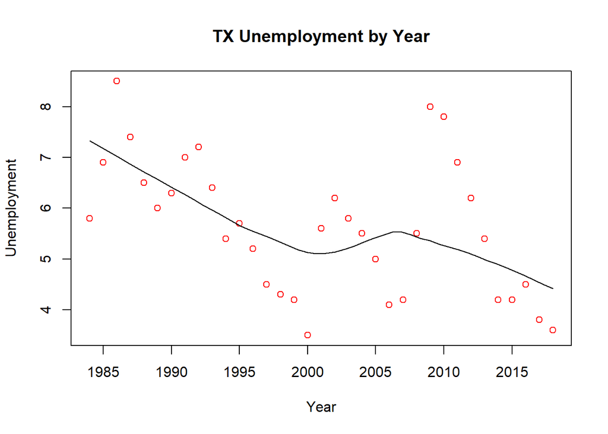

```r
scatter.smooth(x=TX_data$year, y=TX_data$value, main="TX Unemployment by Year", xlab = "Year", ylab = "Unemployment", col = "red")
```

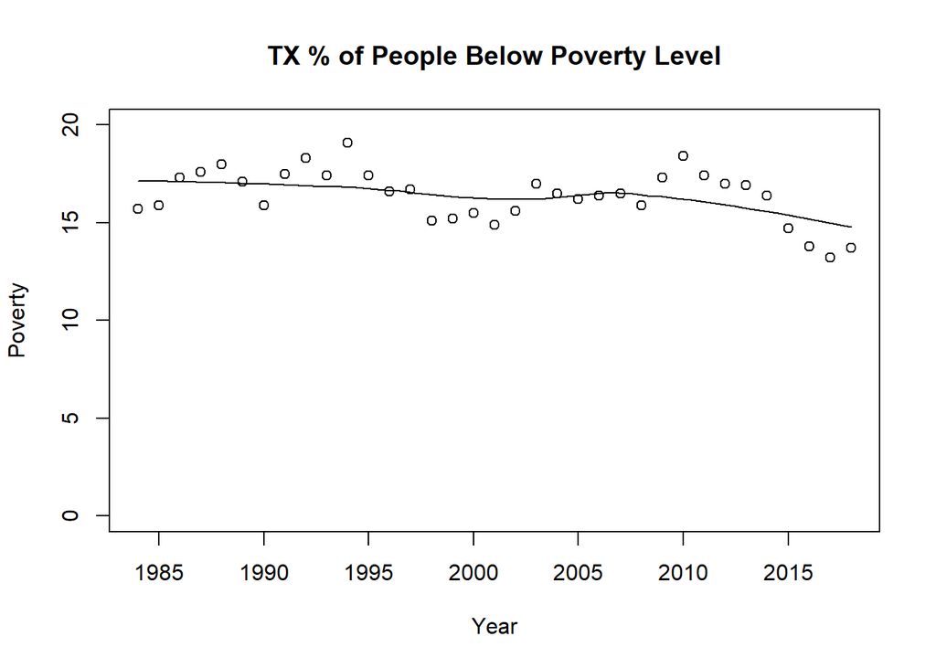

```r
scatter.smooth(x=TX_data$year, y=TX_data$poverty, main="TX % of People Below Poverty Level", xlab = "Year", ylab = "Poverty", ylim = c(0,20))
```

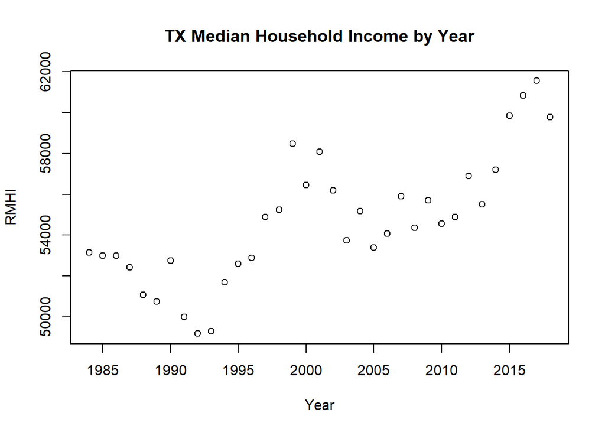

```r
TX_data$RMHI <- as.integer(TX_data$RMHI)
plot(x=TX_data$year, y=TX_data$RMHI, main="TX Median Household Income by Year", xlab = "Year", ylab = "RMHI" )
```

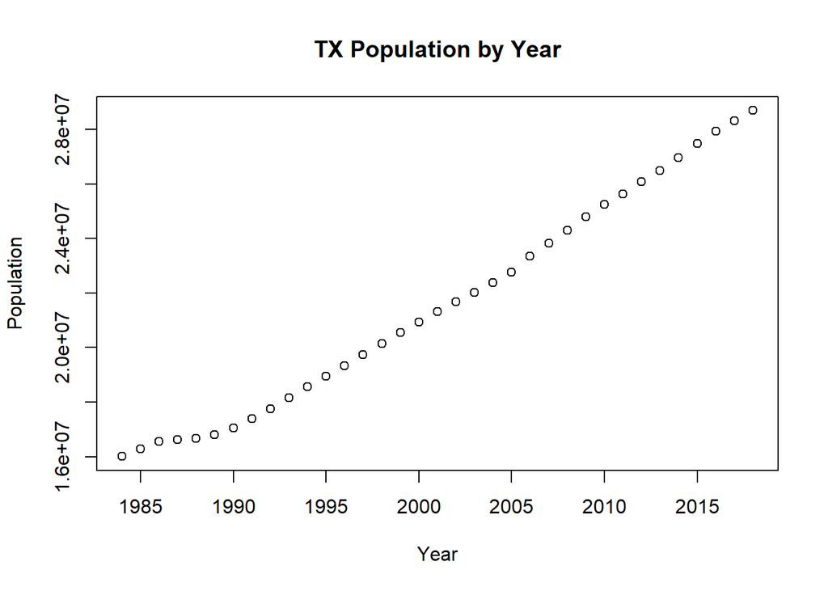

```r
TX_data$population <- as.integer(TX_data$population)
plot(x=TX_data$year, y=TX_data$population, main="TX Population by Year", xlab = "Year", ylab = "Population" )
```

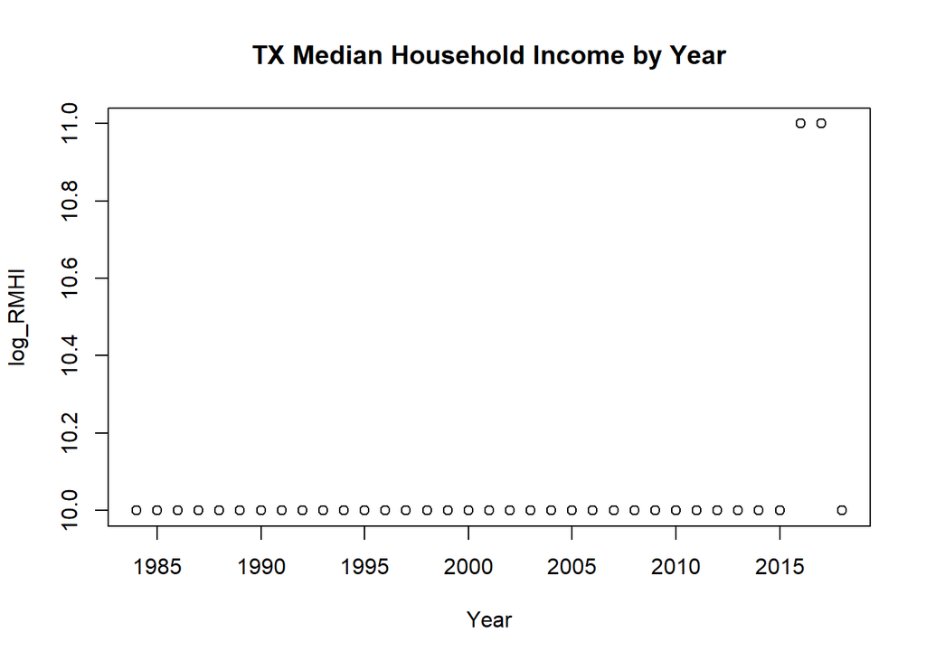

```r
TX_data$log_RMHI <- as.integer(TX_data$log_RMHI)
plot(x=TX_data$year, y=TX_data$log_RMHI, main="TX Median Household Income by Year", xlab = "Year", ylab = "log_RMHI" )
```

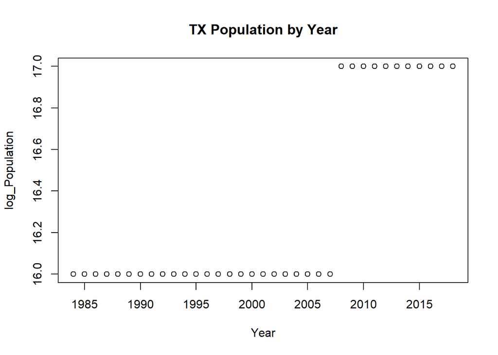

```r
TX_data$log_pop <- as.integer(TX_data$log_pop)
plot(x=TX_data$year, y=TX_data$log_pop, main="TX Population by Year", xlab = "Year", ylab = "log_Population" )
```

```r
cor(TX_data$RMHI, TX_data$value)
```

```
## [1] -0.5663074
```

```r
cor(TX_data$HPI, TX_data$value)
```

```
## [1] -0.4234252
```

```r
cor(TX_data$poverty, TX_data$value)
```

```
## [1] 0.6719098
```

```r
cor(TX_data$population, TX_data$value)
```

```
## [1] -0.3861266
```

```r
cor(TX_data$sp500, TX_data$value)
```

```
## [1] 0.09162901
```

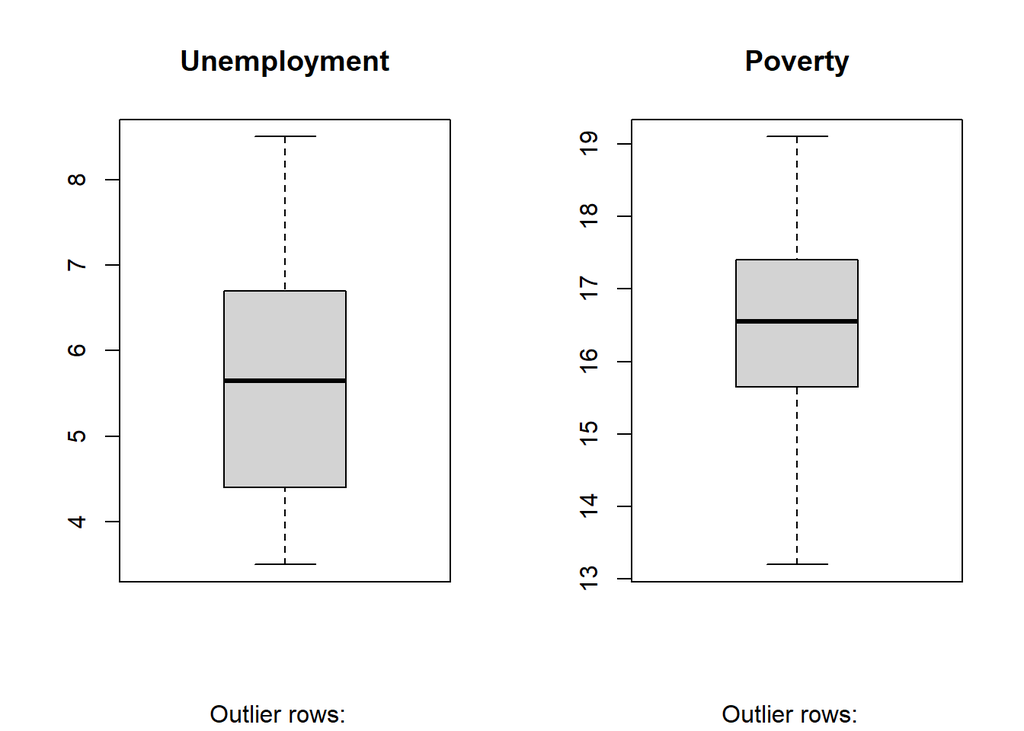

```r
#run base correlations between categories and dependent variable

par(mfrow=c(1, 2))  # divide graph area in 2 columns
boxplot(TX_data$value, main="Unemployment", sub=paste("Outlier rows: ", boxplot.stats(TX_data$value)$out))  # box plot for 'Unemployment'
boxplot(TX_data$poverty, main="Poverty", sub=paste("Outlier rows: ", boxplot.stats(TX_data$poverty)$out))  # box plot for 'Poverty'
```

```r
#create box plot for poverty level and unemployment level

#run multiple linear model for data
TX_reg1 <- lm(value ~ poverty + RMHI + HPI + population + sp500, data = TX_data)
summary(TX_reg1)
```

```
##
## Call:
## lm(formula = value ~ poverty + RMHI + HPI + population + sp500,
##     data = TX_data)
##
## Residuals:
##      Min       1Q   Median       3Q      Max
## -2.42022 -0.50730  0.00617  0.69676  1.87937
##
## Coefficients:
##               Estimate Std. Error t value Pr(>|t|)
## (Intercept) -9.230e+00  1.015e+01  -0.909  0.37042
## poverty      8.773e-01  2.687e-01   3.265  0.00274 **
## RMHI         8.587e-05  1.481e-04   0.580  0.56640
## HPI          2.074e-02  1.448e-02   1.433  0.16225
## population  -3.691e-07  2.264e-07  -1.631  0.11340
## sp500       -4.429e-03  1.126e-02  -0.393  0.69675
## ---
## Signif. codes:  0 '***' 0.001 '**' 0.01 '*' 0.05 '.' 0.1 ' ' 1
##
## Residual standard error: 1.027 on 30 degrees of freedom
## Multiple R-squared:  0.5057, Adjusted R-squared:  0.4234
## F-statistic:  6.14 on 5 and 30 DF,  p-value: 0.0004974
```

```r
anova(TX_reg1)
```

```
## Analysis of Variance Table
##
## Response: value
##            Df Sum Sq Mean Sq F value  Pr(>F)
## poverty     1 28.907 28.9070 27.4029 1.2e-05 ***
## RMHI        1  0.412  0.4118  0.3904  0.5368
## HPI         1  0.057  0.0569  0.0540  0.8179
## population  1  2.844  2.8439  2.6959  0.1111
## sp500       1  0.163  0.1633  0.1548  0.6968
## Residuals  30 31.647  1.0549
## ---
## Signif. codes:  0 '***' 0.001 '**' 0.01 '*' 0.05 '.' 0.1 ' ' 1
```

```r
TX_reg2 <- lm(value ~ poverty + log_RMHI + HPI + log_pop + sp500, data = TX_data)
summary(TX_reg2)
```

```
##
## Call:
## lm(formula = value ~ poverty + log_RMHI + HPI + log_pop + sp500,
##     data = TX_data)
##
## Residuals:
##     Min      1Q  Median      3Q     Max
## -1.9255 -0.5062  0.0000  0.5619  2.1073
##
## Coefficients:
##               Estimate Std. Error t value Pr(>|t|)
## (Intercept) -35.827102  12.387752  -2.892  0.00706 **
## poverty       0.473433   0.172070   2.751  0.00997 **
## log_RMHI      0.760549   0.876899   0.867  0.39265
## HPI          -0.016781   0.005825  -2.881  0.00726 **
## log_pop       1.792295   0.646811   2.771  0.00950 **
## sp500        -0.007592   0.010624  -0.715  0.48037
## ---
## Signif. codes:  0 '***' 0.001 '**' 0.01 '*' 0.05 '.' 0.1 ' ' 1
##
## Residual standard error: 0.94 on 30 degrees of freedom
## Multiple R-squared:  0.586,  Adjusted R-squared:  0.517
## F-statistic: 8.492 on 5 and 30 DF,  p-value: 4.247e-05
```

```r
anova(TX_reg2)
```

```
## Analysis of Variance Table
##
## Response: value
##           Df  Sum Sq Mean Sq F value    Pr(>F)
## poverty    1 28.9070 28.9070 32.7129 3.061e-06 ***
## log_RMHI   1  0.5159  0.5159  0.5838  0.450790
## HPI        1  0.7588  0.7588  0.8587  0.361506
## log_pop    1  6.8870  6.8870  7.7937  0.009034 **
## sp500      1  0.4513  0.4513  0.5107  0.480365
## Residuals 30 26.5098  0.8837
## ---
## Signif. codes:  0 '***' 0.001 '**' 0.01 '*' 0.05 '.' 0.1 ' ' 1
```

```r
TX_linearModelSignificant <- lm(value ~ poverty + population, data = TX_data)
summary(TX_linearModelSignificant)
```

```
##
## Call:
## lm(formula = value ~ poverty + population, data = TX_data)
##
## Residuals:
##      Min       1Q   Median       3Q      Max
## -2.05321 -0.65429 -0.06519  0.73940  2.05219
##
## Coefficients:
##               Estimate Std. Error t value Pr(>|t|)
## (Intercept) -3.339e+00  2.836e+00  -1.177    0.248
## poverty      6.097e-01  1.374e-01   4.437  9.6e-05 ***
## population  -4.595e-08  4.683e-08  -0.981    0.334
## ---
## Signif. codes:  0 '***' 0.001 '**' 0.01 '*' 0.05 '.' 0.1 ' ' 1
##
## Residual standard error: 1.017 on 33 degrees of freedom
## Multiple R-squared:  0.467,  Adjusted R-squared:  0.4347
## F-statistic: 14.46 on 2 and 33 DF,  p-value: 3.096e-05
```

```r
#test to show a scatterplot TX HPI data against year
```